# Notebook

### Web Information Retrieval and Data Mining - Assignment 3

```
Student: van Dijk, Roy (0963283)
```

#### Answer 1.1, Baseline (4p)

- Dense network, at least 3 layers, shaped like a pyramid
  - Last layer: 10 nodes, sigmoid.
  - Loss: categorical cross-entropy. Metric: accuracy
- No preprocessing, regularization. Get at least 70% accuracy.
- Explain design decisions. Discuss performance.
  - Does it overfit (large/growing gap between loss and val_loss)?

```
(length: 0)

Max val score: 73.44%
```

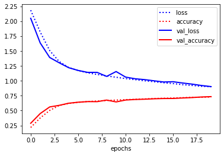

```
Model: "sequential_19"
_________________________________________________________________
Layer (type)                 Output Shape              Param #
=================================================================
reshape_3 (Reshape)          (None, 3072)              0
_________________________________________________________________
dense_23 (Dense)             (None, 128)               393344
_________________________________________________________________
dense_24 (Dense)             (None, 64)                8256
_________________________________________________________________
dense_25 (Dense)             (None, 32)                2080
_________________________________________________________________
dense_26 (Dense)             (None, 10)                330
=================================================================
Total params: 404,010
Trainable params: 404,010
Non-trainable params: 0
_________________________________________________________________
None
def build_model_1_1():
  model = models.Sequential()
  model.add(layers.Reshape((3072,), input_shape=(32,32,3)))
  model.add(layers.Dense(128, activation='relu'))
  model.add(layers.Dense(64, activation='relu'))
  model.add(layers.Dense(32, activation='relu'))
  model.add(layers.Dense(10, activation='softmax'))
  model.compile(optimizer='adamax',loss='categorical_crossentropy',metrics=['accuracy'])
  return model
```

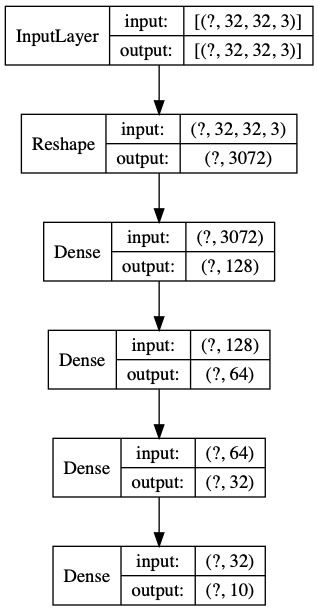

#### Answer 1.2, Preprocess (2p)

- Convert images to greyscale, other preprocessing optional.
  - Input shape should be (32,32,1)
- Explain design decisions. Is it better? Why (not)?
  - Color information is likely not so useful for classification. Greyscale makes the network smaller, less parameters to learn, less likely to overfit.

```
(length: 0)

Max val score: 77.25%
```

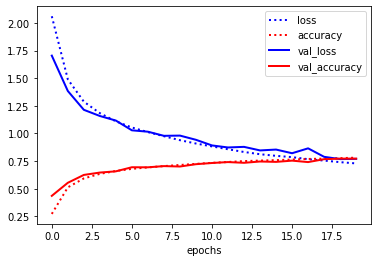

```
Model: "sequential_20"
_________________________________________________________________
Layer (type)                 Output Shape              Param #
=================================================================
reshape_4 (Reshape)          (None, 1024)              0
_________________________________________________________________
dense_27 (Dense)             (None, 128)               131200
_________________________________________________________________
dense_28 (Dense)             (None, 64)                8256
_________________________________________________________________
dense_29 (Dense)             (None, 32)                2080
_________________________________________________________________
dense_30 (Dense)             (None, 10)                330
=================================================================
Total params: 141,866
Trainable params: 141,866
Non-trainable params: 0
_________________________________________________________________
None
def build_model_1_2():
  model = models.Sequential()
  model.add(layers.Reshape((1024,), input_shape=(32,32,1)))
  model.add(layers.Dense(128, activation='relu'))
  model.add(layers.Dense(64, activation='relu'))
  model.add(layers.Dense(32, activation='relu'))
  model.add(layers.Dense(10, activation='softmax'))
  model.compile(optimizer='adamax', loss='categorical_crossentropy', metrics=['accuracy'])
  return model
```

#### Answer 1.3, Tune (4p)

- Regularize the model. What works best?
  - Should consider batch normalization, dropout, l1/l2 regularization (or Nesterov)
- Tune other hyperparameters (e.g. learning rate, batch size,...) as you see fit.
  - At least consider tuning learning rate, ideally also momentum, decay, other optimizers
- Explain your findings and final design decisions. Discuss the results.
  - Should be better, at least it shouldn't overfit

```
(length: 0)

Max val score: 79.53%
```

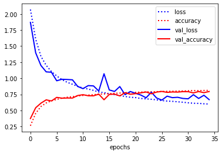

```
def build_model_1_3():
  sgd=optimizers.SGD(lr=0.1)

  model = models.Sequential()
  model.add(layers.Reshape((1024,), input_shape=(32,32,1)))
  model.add(layers.Dense(128, activation='relu'))
  model.add(layers.Dense(64, activation='relu'))
  model.add(layers.Dense(32, activation='relu'))
  model.add(layers.Flatten())
  model.add(layers.Dense(10, activation='softmax'))
  model.compile(optimizer=sgd,loss='categorical_crossentropy',metrics=['accuracy'])
  #model.compile(optimizer='adamax',loss='categorical_crossentropy',metrics=['accuracy'])
  return model
```

#### Answer 2.1, ConvNet (7p)

- Build a sequential ConvNet, get at least 90% accuracy.
  - Conv2D layers, input shape (32,32,1)
  - Consider using blocks of Conv2D layers with maxpooling in between
  - Use zero-padding in Conv2D layers because the images are small
  - At least one dense hidden layer and dense output layer (sigmoid)
  - Consider adding batch normalization, dropout
  - Consider small dropout rates in beginning, larger dropout rates later in network
  - Consider other optimizers and tuning learning rate, momentum,...
- Explain what you did and why (800 chars). Is it working well?
  - Should be quite elaborate and sensible

```
(length: 0)

Max val score: 93.00%
```

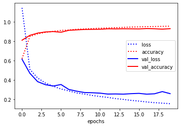

```
Model: "sequential_22"
_________________________________________________________________
Layer (type)                 Output Shape              Param #
=================================================================
conv2d_80 (Conv2D)           (None, 28, 28, 128)       3328
_________________________________________________________________
conv2d_81 (Conv2D)           (None, 24, 24, 64)        204864
_________________________________________________________________
conv2d_82 (Conv2D)           (None, 20, 20, 64)        102464
_________________________________________________________________
dropout_32 (Dropout)         (None, 20, 20, 64)        0
_________________________________________________________________
conv2d_83 (Conv2D)           (None, 16, 16, 32)        51232
_________________________________________________________________
conv2d_84 (Conv2D)           (None, 12, 12, 32)        25632
_________________________________________________________________
dropout_33 (Dropout)         (None, 12, 12, 32)        0
_________________________________________________________________
flatten_13 (Flatten)         (None, 4608)              0
_________________________________________________________________
dense_35 (Dense)             (None, 10)                46090
=================================================================
Total params: 433,610
Trainable params: 433,610
Non-trainable params: 0
_________________________________________________________________
None
def build_model_2_1():
  model = models.Sequential()
  model.add(layers.Convolution2D(128, kernel_size=(5, 5), strides=(1, 1), activation='relu',
                                          input_shape=(32,32,1)))
  model.add(layers.Convolution2D(64, (5, 5), activation='relu'))
  model.add(layers.Convolution2D(64, (5, 5), activation='relu'))
  model.add(layers.Dropout(0.2))
  model.add(layers.Convolution2D(32, (5, 5), activation='relu'))
  model.add(layers.Convolution2D(32, (5, 5), activation='relu'))
  model.add(layers.Dropout(0.2))
  model.add(layers.Flatten())
  model.add(layers.Dense(10, activation='softmax'))
  model.compile(optimizer='adamax',loss='categorical_crossentropy',metrics=['accuracy'])
  return model
```

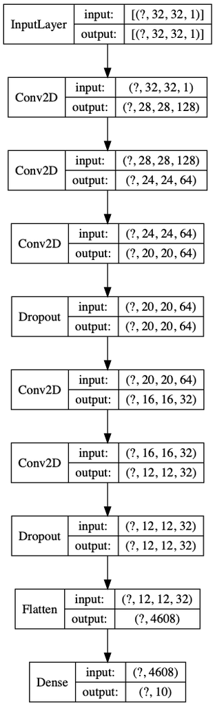

#### Answer 2.2, Data Augmentation (3p)

- Augment the preprocessed training data.
  - Use small variations (small shifts up-down, left-right) of flips becasue the images are small
  - Large shifts and rotations distort the image too much
- Explain what you did and why. Discuss the performance of the model.

```
(length: 0)

Max val score: 86.05%
```

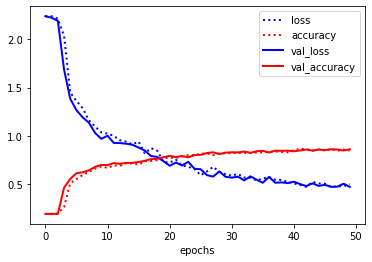

```
  datgen = ImageDataGenerator(rotation_range=30)
```

#### Answer 3.1, Misclassifications (2p)

```
(length: 0)

Test score: 0.07%
[[   0    0    0    3    0  715  336 2738    0    0]
 [   0    0    0   19    0  287  633 2008    0    0]
 [   0    0    0    4    0  227  403 1642    0    0]
 [   0    0    0   15    0  421  218 1342    0    0]
 [   0    0    0    3    0  266  222 1362    0    0]
 [   0    1    0    2    0  173  216 1149    0    0]
 [   0    0    0    7    0  104  158 1254    0    0]
 [   0    0    0    4    0  131  112 1092    0    2]
 [   0    0    0    3    0  122  185  941    0    0]
 [   0    0    0    2    0  132  157 1045    0    2]]



               precision    recall  f1-score   support

           0       0.00      0.00      0.00      3792
           1       0.00      0.00      0.00      2947
           2       0.00      0.00      0.00      2276
           3       0.24      0.01      0.01      1996
           4       0.00      0.00      0.00      1853
           5       0.07      0.11      0.08      1541
           6       0.06      0.10      0.08      1523
           7       0.07      0.81      0.14      1341
           8       0.00      0.00      0.00      1251
           9       0.50      0.00      0.00      1338

    accuracy                           0.07     19858
   macro avg       0.09      0.10      0.03     19858
weighted avg       0.07      0.07      0.02     19858
```

#### Answer 3.2, Activations (4p)

- Retrieve and visualize the activations for one example
- For every filter for different convolutional layers (at different depths in the network).
- Give an explanation. Is your model indeed learning something useful?
  - Should detect edges etc in first layers, higher-order object (e.g. interesting regions) in deeper layers.

```
(length: 0)
```

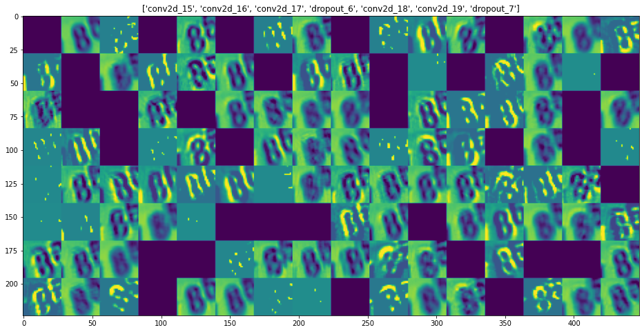

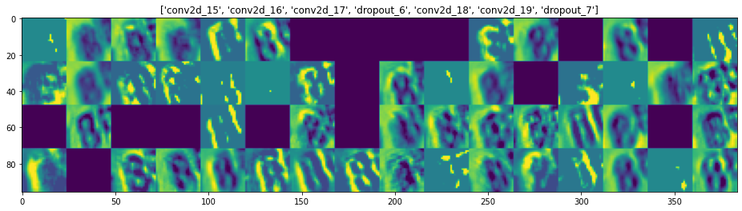

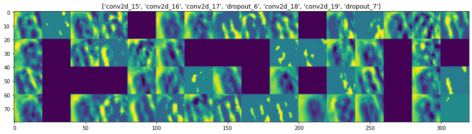

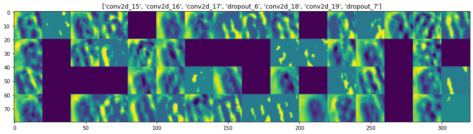

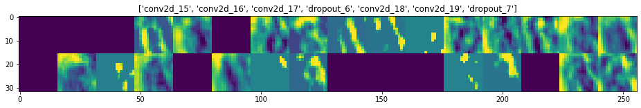

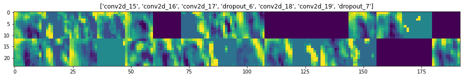

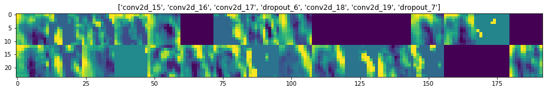

#### Answer 3.3, Class activation map (4p)

- Show a class activation map for your last convolutional layer
- Superimpose the activation map over the image, or plot side by side
  - Should make sense, detect interesting regions to classify the number

[figure not shown]

```
def plot_activation_map(x):
  stop_training = True
  model=run_evaluation("model_2_2", build_model_2_1,preprocessed_split, base_dir,
                       train=False, epochs=20, batch_size=64)
  gap_weights = model.layers[-1].get_weights()[0]
  gap_weights.shape
  # Taking first image from testset and reshape it
  img=x[0]
  test_img_1 = np.expand_dims(img, axis=0)
  test_img_1 /= 255.
  activation_model  = models.Model(inputs=model.input,outputs=(model.layers[-3].output,model.layers[-1].output))
  activation_model.summary()
  features,r = activation_model.predict(x[0])
  #features.shape
  cm_weights = activation_model.layers[-3].get_weights()[0]
  cm_weights.shape
  pred=np.argmax(r)
  #cc_weigh=gap_weights[:,pred]
  #c_output=np.dot(features,cc_weigh)
  plt.imshow (c_output, cmap = 'jet', alpha = 0.5)
  plt.show()
```

#### Answer 4.1, Fast feature extraction (5p)

- Import the VGG16 model, pretrained on ImageNet
- Freeze convolutional base, adds a dense layer
- Consider unfreezing the last few convolutional layers and evaluate whether that works better
  - Check if they do. It is very likely to help.
- Discuss the observed performance
  - Should get around 80% accuracy

```
(length: 0)

Max val score: 98.17%
```

[figure not shown]

```
Model: "model_2"
_________________________________________________________________
Layer (type)                 Output Shape              Param #
=================================================================
image_input (InputLayer)     [(None, 32, 32, 3)]       0
_________________________________________________________________
vgg16 (Model)                multiple                  14714688
_________________________________________________________________
flatten (Flatten)            (None, 512)               0
_________________________________________________________________
Dense_layer (Dense)          (None, 64)                32832
_________________________________________________________________
out_layer (Dense)            (None, 10)                650
=================================================================
Total params: 14,748,170
Trainable params: 14,748,170
Non-trainable params: 0
_________________________________________________________________
None
def build_model_4_1():
  # Load the model
  vgg16_model = VGG16(include_top=False, weights='imagenet')
  #vgg16_model.summary()
  # Creating own input format (here 32,32,2)
  input = Input(shape=(32,32,3), name = 'image_input')
  output_vgg16_conv = vgg16_model(input)
  # Add the fully-connected layers
  m = Flatten(name='flatten')(output_vgg16_conv)
  m = Dense(64, activation='relu', name='Dense_layer')(m)
  m = Dense(10, activation='softmax', name='out_layer')(m)
  modified_model = Model(input=input, output=m)
  #modified_model.summary()
  modified_model.compile(optimizer='adamax', loss='categorical_crossentropy', metrics=['accuracy'])
  return modified_model
```

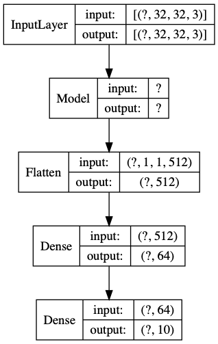

#### Answer 4.2, Embeddings (5p)

- Generate embeddings with the trained convolutional part of model_4_1 (without the dense layer)
- Embed the training and test data and store them to disk
- Build and evaluate a pipeline on the embedded data
  - Check if pipeline makes sense (e.g. use models that can handle many dimensions)
- Describe what you did and what you observed (max 800 chars).
  - Consider different models, preprocessing, tuning, etc.
  - Check performance (see original Submission.html) when in doubt. We did not run all the evaluations because it takes too long, and the output is ill-defined.

[output not shown]

```
Running time: 9.30 seconds
Last modified: May 26, 2020
scikit-learn version: 0.23.1
```